# Effects of Trip Duration, Distance and Bike Share for all Trip on User Type for Bike Sharers in the Greater San Francisco Bay Area (Februray 2019)

## by Oluwafunmilayo Chinonye Samuel

## Investigation Overview

The exploration focused on the effects of trip duration, distance, and bike share for all trip on user type. This presentation begins with an introduction of the individual distribution for the four variables, and then proceeds with the individual and combined effects of the variables on user type. Insights on the strong relationship between trip duration and distance are also displayed.

## Dataset Overview

The dataset contained 174952 bike share rides with column entries for the user type, trip duration, distance, and bike share for all trip amongst other useful variables like time, gender, and day categories which were briefly displayed at the end of the presentation. A total of 622 datapoints, identified as outliers, were removed during the analysis.

## Distribution of User Type

The user type is a categorical variable with two categories namely 'Subscriber', and 'Customer'. 91% of the bike sharers are Subscribers, and the remaining 9% are Customers.

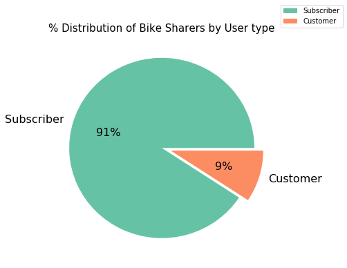

## Age Distribution

The majority of the bike sharers age between 20 and 40 years, with the peak age at about 31 years.The boxplot and the histogram indicate that the age distribution is right skewed, although unimodal. However, the distribution is logical because, based on the number of trips, younger people should bike more frequently than older people.

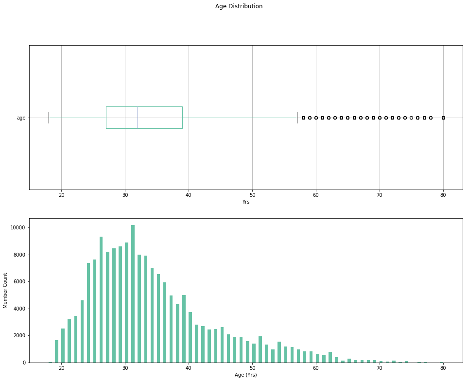

## Distribution of Trip Duration

The distribution is skewed to the right, although unimodal with a peak point at 0.1hrs (6mins) just like the age distribtuion. The trip duration is concentrated between 0.01hrs (less than 1min) and 0.4hrs (24mins).

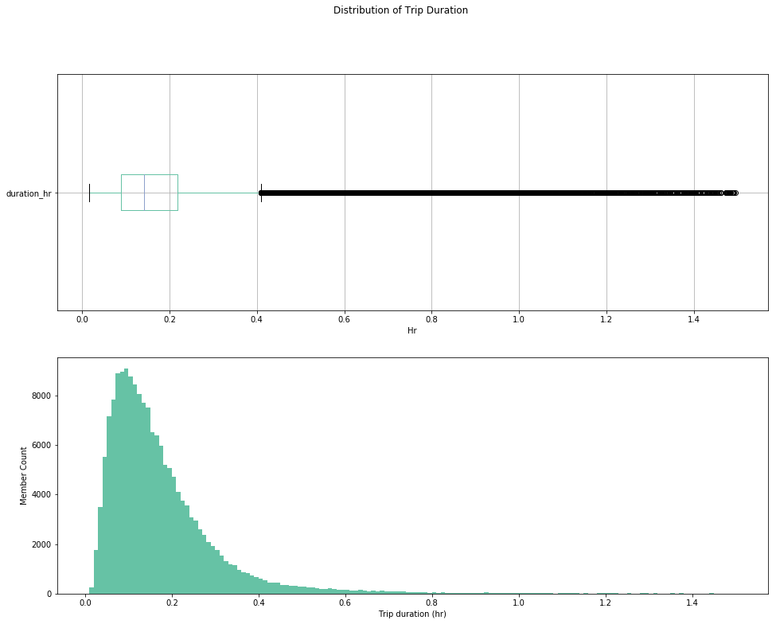

## Distribution of Distance

Distance represents the distance from the start to the end stations, and not the entire trip. Its distribution is also right skewed, and seems bimodal with peak points between 1km and 1.6km. 0km represents the distance for trips where the start and end station was the same.

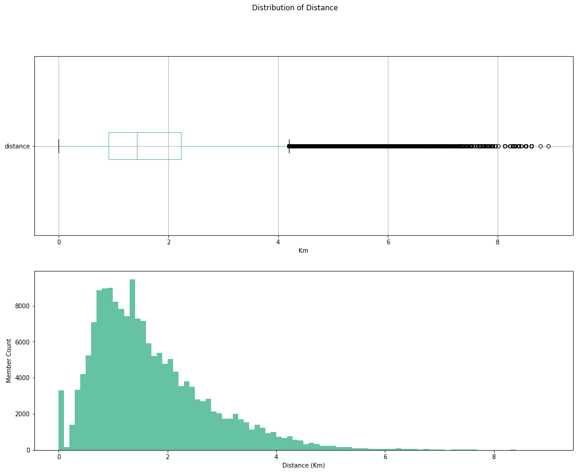

## Distribution of Bike Use for the Entire Trip

The majority of the bike sharers use the bike for only a part of their trips.

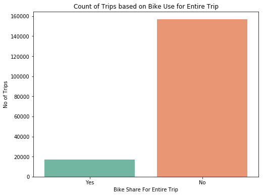

## Differences between User Types based on Trip Duration

Based on the median and quartile, the trip duration for customers is significantly higher than that of subscribers. The range for the trip durations differ significantly for customers (between 0.1hr and 1hr) and subscribers (between 0.1hr and 0.7hr). Furthermore, the probability that the trip duration of subscribers is 0.1hr (roughly 6mins) is very high. On the other hand, customers have a trip duration of 0.25km (roughly 15mins), and the probability is less than than of the subscribers. This is not surprising because subscribers tend to be daily commuters to a defined place of work or study, and some might need to travel longer distances than others.

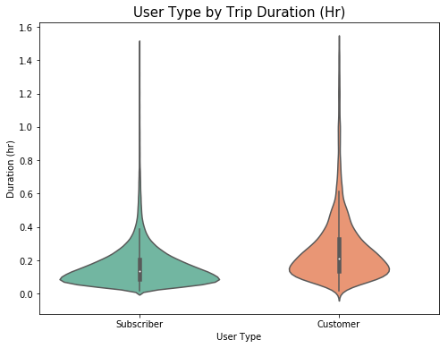

## Differences between User Types based on Distances

This insight can also imply the possibility of a correlation between trip duration and distance. This will not be surprising because distance is a part of the trip duration.

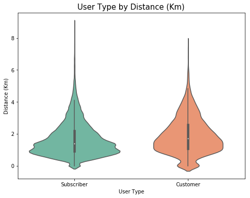

## Effect of Distance on Trip Duration

NB: The regression values can change because of the random sampling technique.

[figure not shown]

## Differences between User Types based on Bike Share for Entire Trip

It is interesting that only subscribers use the shared bike for an entire trip, while customers use the shared bike for only a part of their trips. The violin plots on user type by trip duration confirmed that subscribers tend to travel shorter distances compared with customers.

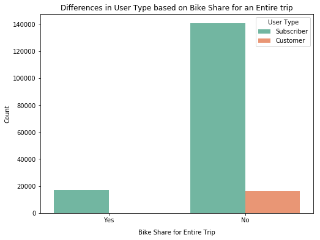

## Relationship between Trip Duration, Distance and Bike share for all trip for Subscribers

The barplot from the bivariate data exploration established that only subscribers use the bike share for the entire trip. Therefore, the relationship between trip duration, distance and bike share for all trip can be attributed to the subscribers.

The plot below confirms the assumption that most subscribers travelled to a defined location either for study or work, and some travelled longer distances than others. The concentration of subscribers that used the bike share for the entire trip travelled between 0.2km and about 2km with a trip duration between 0.01 (less than a minute) and 0.2hrs (12mins). Some subscibers also returned the shared bikes to the start station.

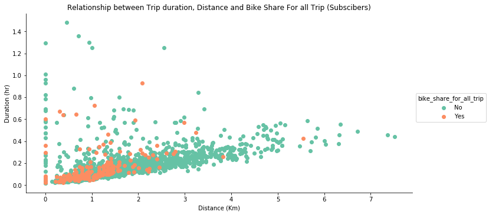

## Additional Insights: Differences between User Types based on Trip Duration and Gender

Although gender had no significant effect on user type when considered as a single variable, it revealed some interesting insights when combined with the trip duration. The females (0.17hrs or 10mins) bike slightly longer than the males (0.14hrs or 8mins), and others (0.16hrs or 9mins) across user types. This insight presents a deviation from current research trends on trip duration between males and females.

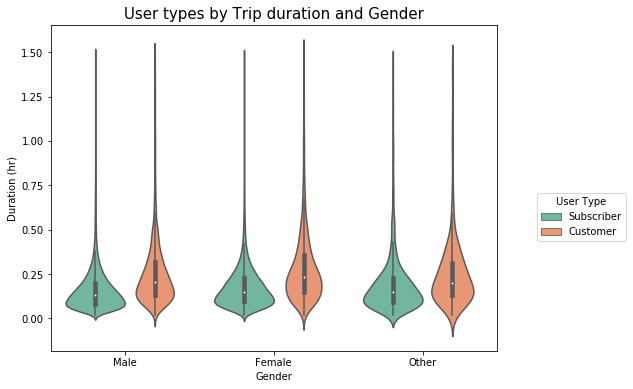

## Additional Insights: Differences between User Types based on Trip Duration and Day Category

While day category initially had no effect on user type, an effect was discovered in combination with trip duration. There are significant differences between the trip duration of customers and subscribers on Weekdays and Weekends. While there is no marked difference between the median trip duration for subscribers during the weekdays and weekends, there is a very significant difference between the trip duration for customers on Weekdays and Weekends. The fact that customers tend to ride longer distances compared with subscribers has already been established. Therefore, the key insight here is the fact that more customers use the shared bikes during the weekends, and travel longer distances. This could be for recreation purposes.

NB: Weekends include Saturdays and Sundays, while Weekdays range from Mondays to Fridays.

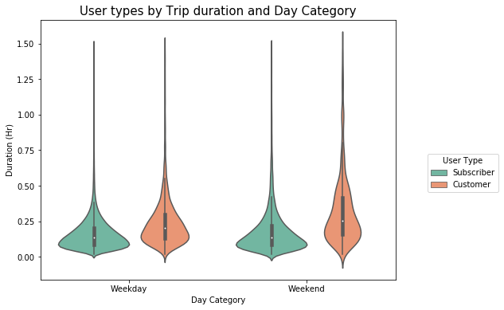

## Additional Insights: Differences between User Types based on Trip Duration and Time

NB: morning - 6 to 12; afternoon - 12 to 17; early evening - 17 to 20; late evening - 21 to 23; night - 0 to 6

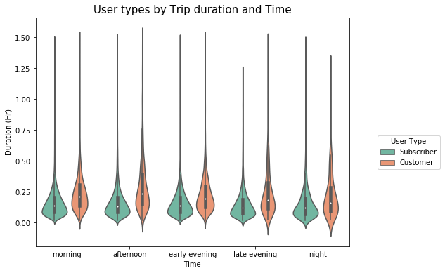